# Bellabeat Analysis - Capstone Project

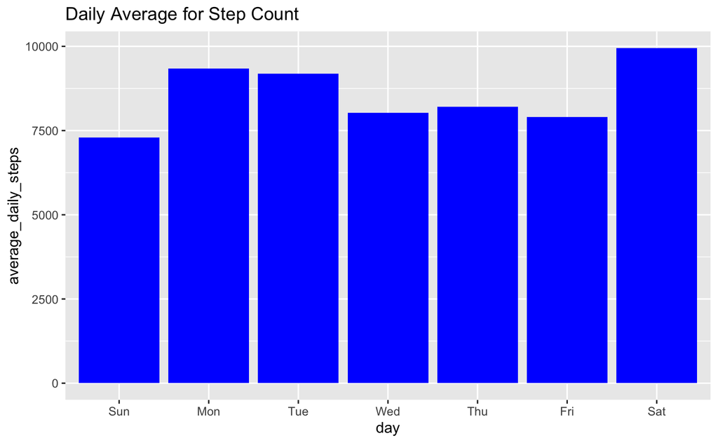

```r
ggplot(data = sum_sleep_daily_activity, mapping=aes(x=day, y=average_daily_steps)) +
  geom_col(fill="blue") + labs(title="Daily Average for Step Count")
```

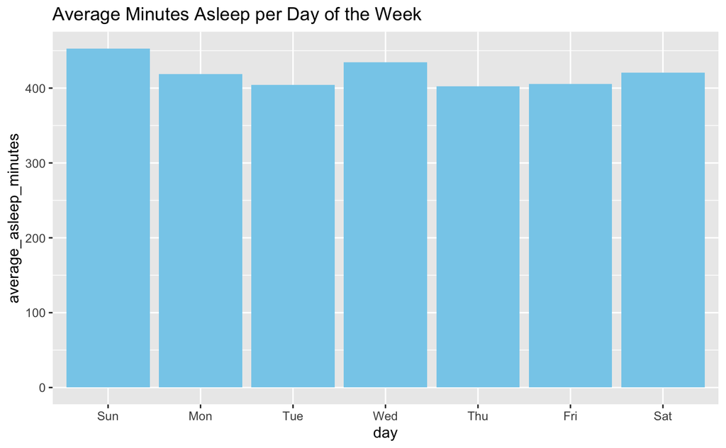

```r
ggplot(data = sum_sleep_daily_activity, mapping=aes(x=day, y=average_asleep_minutes)) +
  geom_col(fill="sky blue") + labs(title="Average Minutes Asleep per Day of the Week")
```

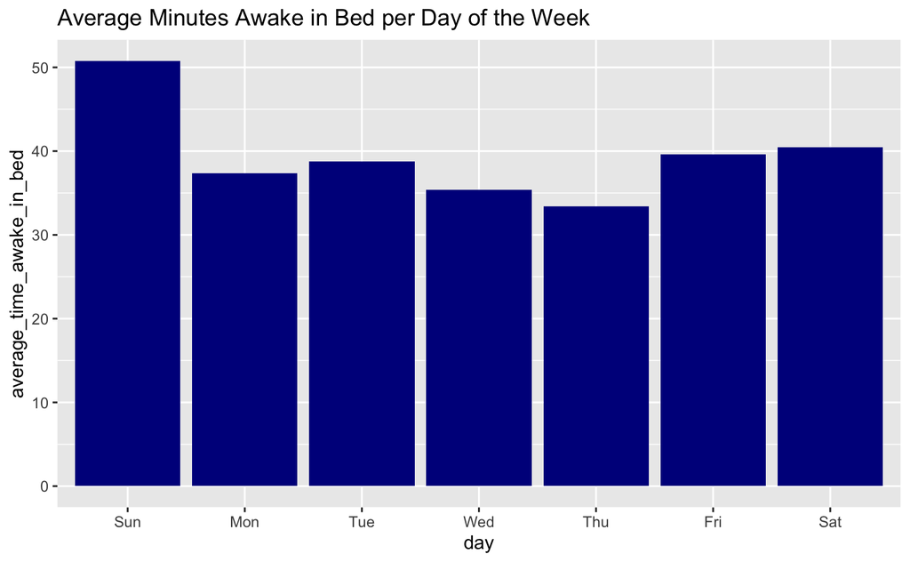

```r
ggplot(data = sum_sleep_daily_activity, mapping=aes(x=day, y=average_time_awake_in_bed)) +
  geom_col(fill="dark blue") + labs(title="Average Minutes Awake in Bed per Day of the Week")
```

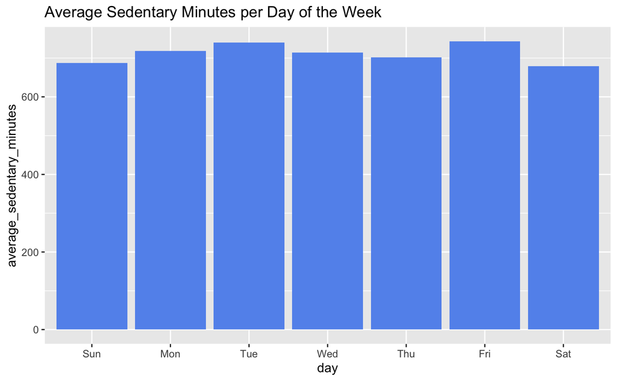

```r
ggplot(data = sum_sleep_daily_activity, mapping=aes(x=day, y=average_sedentary_minutes)) +
  geom_col(fill="cornflowerblue") + labs(title="Average Sedentary Minutes per Day of the Week")
```

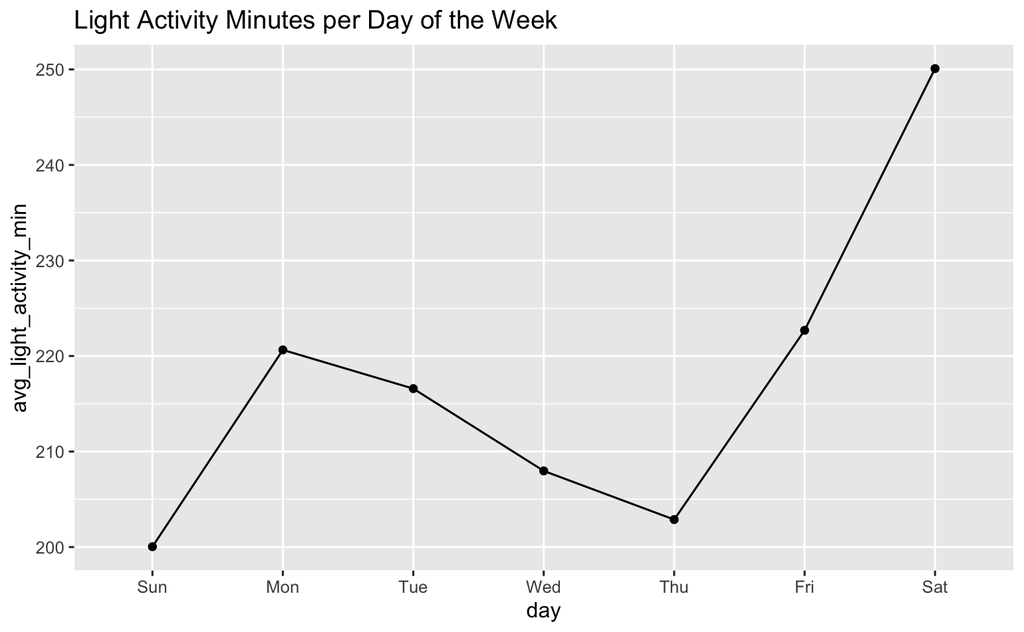

```r
ggplot(data=sum_sleep_daily_activity,mapping=aes(x=day)) +
  geom_line(mapping=aes(y=avg_light_activity_min, group=1)) + geom_point(aes(y=avg_light_activity_min)) +
  labs(title="Light Activity Minutes per Day of the Week")
```

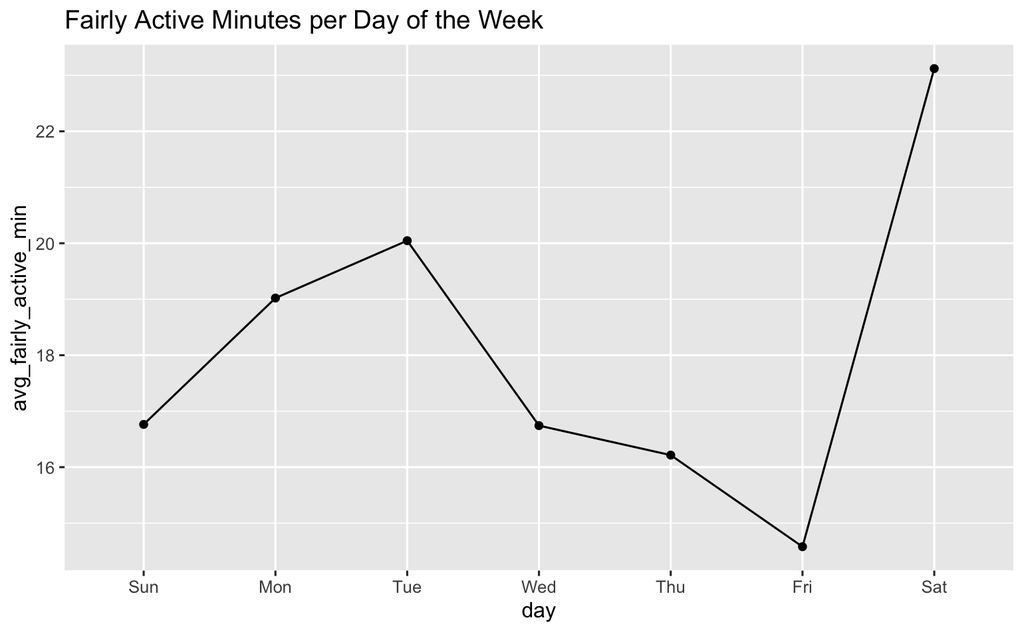

```r
ggplot(data=sum_sleep_daily_activity,mapping=aes(x=day)) +
  geom_line(mapping=aes(y=avg_fairly_active_min, group=1)) + geom_point(aes(y=avg_fairly_active_min)) +
  labs(title="Fairly Active Minutes per Day of the Week")
```

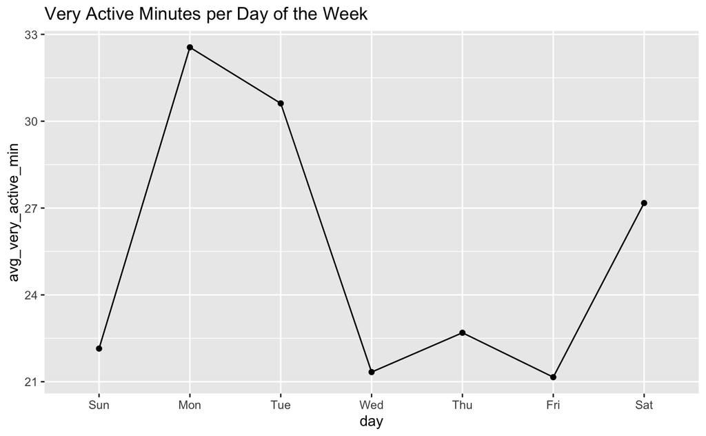

```r
ggplot(data=sum_sleep_daily_activity,mapping=aes(x=day)) +
  geom_line(mapping=aes(y=avg_very_active_min, group=1)) + geom_point(aes(y=avg_very_active_min)) +
  labs(title="Very Active Minutes per Day of the Week")
```

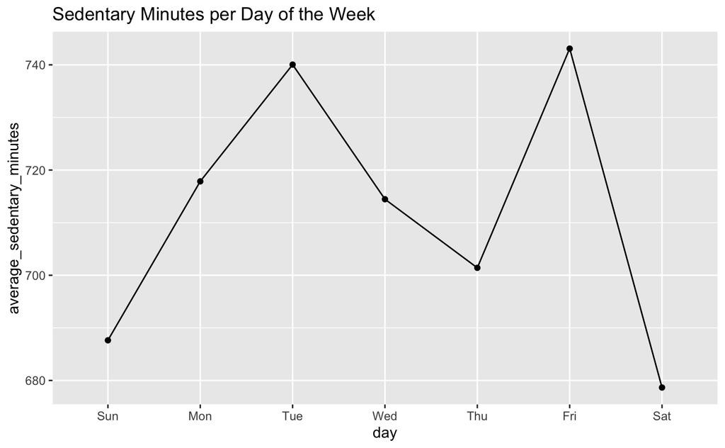

```r
ggplot(data=sum_sleep_daily_activity,mapping=aes(x=day)) +
  geom_line(mapping=aes(y=average_sedentary_minutes, group=1)) + geom_point(aes(y=average_sedentary_minutes)) +
  labs(title="Sedentary Minutes per Day of the Week")
```

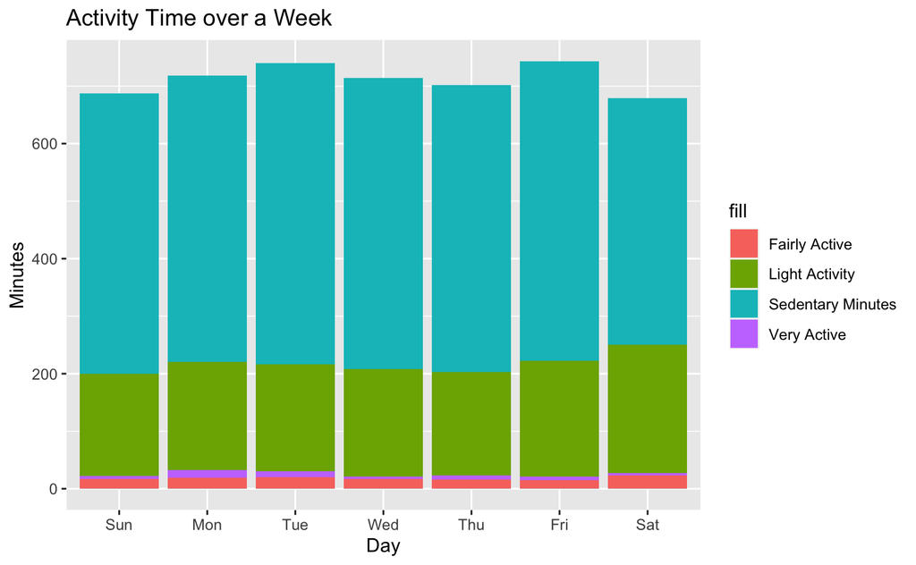

```r
ggplot(data=sum_sleep_daily_activity,mapping=aes(x=day)) +
  geom_col(mapping=aes(y=average_sedentary_minutes, group=1, fill='Sedentary Minutes')) +
  geom_col(mapping=aes(y=avg_light_activity_min, group=1, fill='Light Activity')) +
  geom_col(mapping=aes(y=avg_very_active_min, group=1, fill='Very Active')) +
  geom_col(mapping=aes(y=avg_fairly_active_min, group=1, fill='Fairly Active')) +
  labs(x='Day',y='Minutes',title='Activity Time over a Week')
```

> Observing the `Activity Time over a Week` plot, we can observe that users stay most active on Saturdays, and most likey to not do anything on Sundays. There is a peak sedentary minutes on Friday, potentially due to the end of the work week and users would rather relax instead of exercise. Lastly, Mondays and Tuesdays are when people feel most energetic to have some active minutes, as light, fair, and very active minutes all have an increase here.

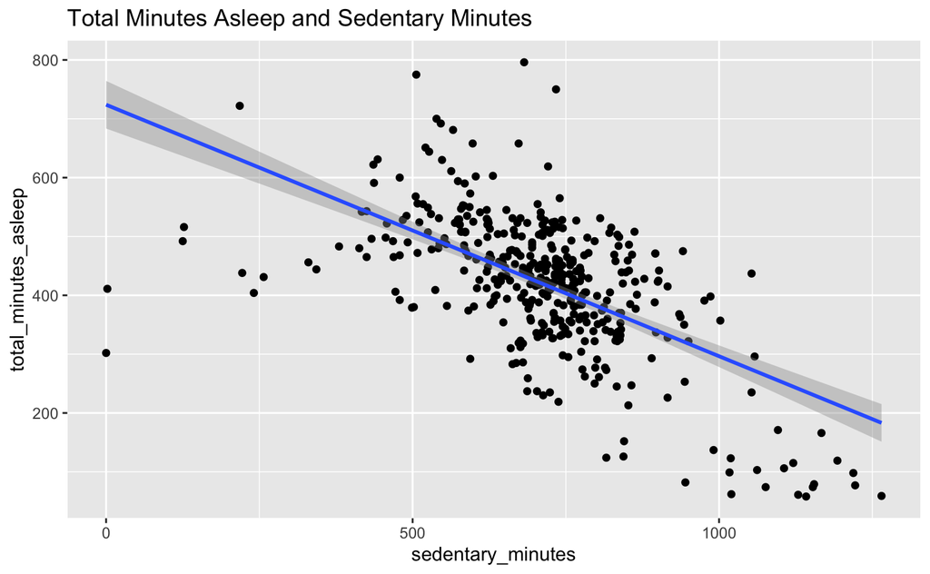

```r
ggplot(data=combined_sleep_daily_activity, mapping=aes(x=sedentary_minutes, y=total_minutes_asleep)) +
  geom_point() + geom_smooth(formula = y ~ x, method='lm') + labs(title= "Total Minutes Asleep and Sedentary Minutes")
```

```r
cor(combined_sleep_daily_activity$total_minutes_asleep,combined_sleep_daily_activity$sedentary_minutes)
```

```
[1] -0.599394
```

> A relationship between the amount of sedentary minutes and total minutes asleep exists, a negative correlation of -0.60 explains the less active a user is, the less time asleep a user will get. We can further assume that the less energy consumed through excerise means we won’t be as tired to go to sleep.

## Act

**Moving forward** * With the goal to have users be more active no matter the intensity, encourage users to take more steps per hour with a possible goal for a step counter or just notify user to stand and take a small walk. * Let users set activity goals so the metrics measured like heartrate, activity, intensity, steps, and distance is comparable to themselves, it would be biased to compare one’s daily metrics to another’s and try to gain insights from it.